# Lecture 25 - Into Deep Learning

This is an [R Markdown](http://rmarkdown.rstudio.com) Notebook

http://www.rubiksplace.com/speedcubing/F2L-algorithms/

### Lecture 25 - Your project. Deep Learning

Deep Learning… In this lecture I would like to esplore with you the DeepLearning we can do with H2O package in R…

#### Learning to do Deep Learning

Inspired from (https://dzone.com/articles/anomaly-detection-with-deep-learning-in-r-with-h2o)[https://dzone.com/articles/anomaly-detection-with-deep-learning-in-r-with-h2o]

Also used: (https://dzone.com/articles/the-basics-of-deep-learning-how-to-apply-it-to-pre?fromrel=true)[https://dzone.com/articles/the-basics-of-deep-learning-how-to-apply-it-to-pre?fromrel=true]

And: (https://shiring.github.io/machine_learning/2017/05/01/fraud)[https://shiring.github.io/machine_learning/2017/05/01/fraud]

In this lecture we would explore the ‘technology’ on the sample and try to do this in 10 min lecture!

##### Understanding architecture

The ‘Thing’ will be working on your computer. In fact you will install another ‘computer’ inside your ‘computer’…

##### Installing from R and starting it up

These instructions I got from: (http://h2o.ai/download/)[http://h2o.ai/download/]. Simply use ‘Install from R’ option

```r
# The following two commands will remove any previously installed H2O packages for R.
if ("package:h2o" %in% search()) { detach("package:h2o", unload=TRUE) }
if ("h2o" %in% rownames(installed.packages())) { remove.packages("h2o") }

# Next, we download packages that H2O depends on.
pkgs <- c("statmod","RCurl","jsonlite")
for (pkg in pkgs) {
if (! (pkg %in% rownames(installed.packages()))) { install.packages(pkg) }
}

# Now we download, install and initialize the H2O package for R.
install.packages("h2o", type="source", repos="http://h2o-release.s3.amazonaws.com/h2o/rel-weierstrass/7/R")

# Finally, let's load H2O and start up an H2O cluster
library(h2o)
h2o.init()
```

As you see this will actually start the ‘cluster’ on our machine! We will now can look on `Localhost:54321` to see the ‘interface’ of our cluster…

As a trial let’s learn how to shut down the machine…

```r
# we can shut down the 'machine' like this...
h2o.shutdown(prompt= FALSE)
```

# Explore the thing on ‘example’

We will now run the demo from H2O. First thing we will launch the machine again…

```r
# to load the library
library(h2o)

# to initialize the 'machine'
h2o.init()
```

Then we will download the datasets from h2o.

```r
# Import ECG train and test data into the H2O cluster
train_ecg <- h2o.importFile(
 path = "http://h2o-public-test-data.s3.amazonaws.com/smalldata/anomaly/ecg_discord_train.csv",
 header = FALSE,
 sep = ",")
test_ecg <- h2o.importFile(
 path = "http://h2o-public-test-data.s3.amazonaws.com/smalldata/anomaly/ecg_discord_test.csv",
 header = FALSE,
 sep = ",")
```

Personally I like to know what is in the data and how it look like!!! I will just use this link and put it into the browser. This will download the files with raw data. If I open this dataset it would not tell me much! I will plot this data in excel…

**Train data set**

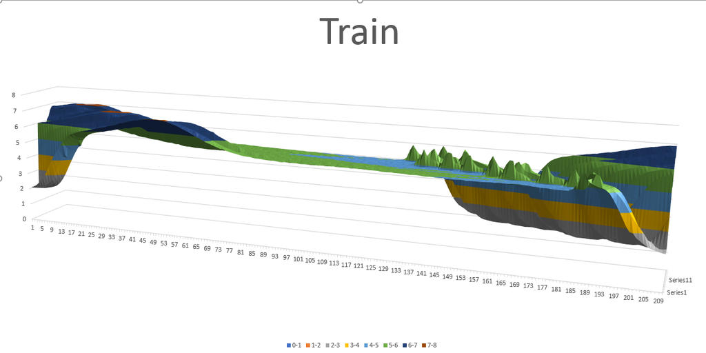

**Test data set**

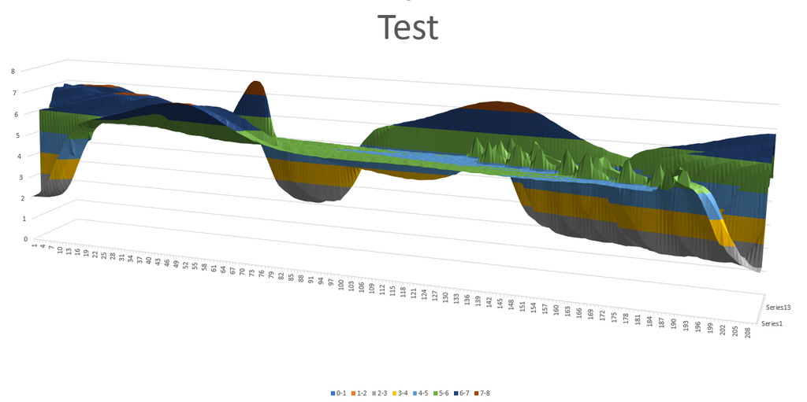

Or, I can also pull the data from h2o with

```r
# data frame for training dataset
df_train <- as.data.frame(train_ecg)
# data frame for test dataset
df_test <- as.data.frame(test_ecg)
```

from there we can see that the difference between both are in the three new rows 21-23

Now, once we know how our data looks like we can start to do our Anomaly Model

```r
# Train deep autoencoder learning model on "normal"
# training data, y ignored
anomaly_model <- h2o.deeplearning(
 x = names(train_ecg),
 training_frame = train_ecg,
 activation = "Tanh",
 autoencoder = TRUE,
 hidden = c(50,20,50),
 sparse = TRUE,
 l1 = 1e-4,
 epochs = 100)
```

Once our model is made, we can use it to detect anomalies in our **test** dataset

```r
# Compute reconstruction error with the Anomaly
# detection app (MSE between output and input layers)
recon_error <- h2o.anomaly(anomaly_model, test_ecg)

# Pull reconstruction error data into R and
# plot to find outliers (last 3 heartbeats)
df_recon_error <- as.data.frame(recon_error)
df_recon_error
```

[output not shown]

We can plot this as well

```r
plot.ts(df_recon_error)
```

[output not shown]

Now we can obtain predictions, or physical values using our model. We should provide the model and test dataset

```r
# Note: Testing = Reconstructing the test dataset
test_recon <- h2o.predict(anomaly_model, test_ecg)
```

```r
head(test_recon)
```

In order to make things visible. Once again I ask excel to help… Here I simply write teh dataframe to csv and create graph in excel

```r
predicted <- as.data.frame(test_recon)
write.csv(predicted, "test_predicted.csv")
```

**Predicted data set**

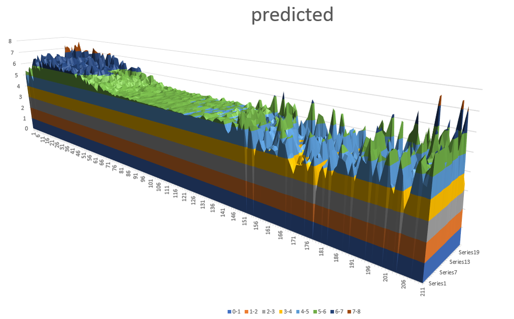

To use our model in our ShinyApp we will save it…

```r
h2o.saveModel(anomaly_model, "C:/Users/fxtrams/Downloads/tmp/anomaly_model.bin")
h2o.download_pojo(anomaly_model, "C:/Users/fxtrams/Downloads/tmp", get_jar = TRUE)
```

And let’s not forget to switch off our cluster!

```r
h2o.shutdown(prompt= FALSE)
```

#### Conclusion

In this example the Anomaly Detection model was able to output the anomaly in rows 21-23.

It learned on the pattern of many vectors and was able to distinguish the anomaly coming on new dataset

Practical use of this model can be to us function **h2o.anomaly**. In case the MSE value will be high - the anomaly is detected!

##### Next step

our next step will be to repeat the procedure but on our machine data.

- arranging data to many vectors
- learning the models
- testing the models
- saving models

Once we can have our model ready next step will be implementation in our ShinyApp…